# forestsearch examples

# Introduction

## What is ForestSearch?

ForestSearch is an R package for identifying patient subgroups with differential treatment effects in survival data. It combines:

- **Machine Learning**: GRF (Generalized Random Forests) for variable selection
- **Statistical Methods**: Cox regression, LASSO dimension reduction
- **Validation**: Consistency analysis across random splits
- **Parallelization**: Efficient computation for large datasets

## Key Features

- **Subgroup Identification:** Finds subgroups with differential treatment effects using combinations of confounders.
- **Variable Selection:** Supports LASSO (for dimension reduction), and Generalized Random Forests (GRF) for candidate cut selection.
- **Flexible Cut Strategies:** Allows for forced cuts (e.g., “age <= 65”, “biomarker < 1%”, “biomarker < 2%”, …, “biomarker < 10%”, etc), median cuts, and quantile cut strategies.
- **Parallelization:** Supports parallel processing for efficiency.
- **Consistency Analysis:** Evaluates the consistency of identified subgroups across splits or bootstraps.

## Main Arguments

- `df.analysis`: Data frame for analysis.
- `outcome.name`, `event.name`, `treat.name`, `id.name`: Variable names for outcome, event, treatment, and ID.
- `confounders.name`: Names of confounder variables.
- `parallel_args`: List for parallelization (plan, workers).
- `use_lasso`, `use_grf`: Logical; use LASSO or GRF for variable selection.
- `conf_force`: Allows for pre-specified subgroup (e.g., “age <= 65”, “biomarker <= low”).
- `n.min`, `hr.threshold`, `hr.consistency`, `sg_focus`, `fs.splits`, `stop.threshold`, `pconsistency.threshold`: Subgroup search and consistency parameters.
- `details`: Logical; print details during execution.

# ForestSearch Parameter Guide: hr.threshold, hr.consistency, and pconsistency.threshold

## Overview

These three parameters control the **effect size requirements** and **reproducibility standards** for subgroup identification. They act as filters to ensure identified subgroups show both clinically meaningful and statistically stable treatment effects.

## Parameter Definitions

### `hr.threshold` - Initial Hazard Ratio Threshold

- **Default**: 1.25
- **Purpose**: Minimum treatment effect required for initial subgroup consideration
- **Range**: 1.0 (any effect) to 2.0+ (large effects only)
- **Interpretation**: HR > 1.25 means treatment is at least 25% worse in this subgroup

### `hr.consistency` - Consistency Hazard Ratio Threshold

- **Default**: 1.0
- **Purpose**: Minimum HR required in random split-sample validation
- **Range**: 0.8-1.0 (lenient) to 1.25+ (strict)
- **Interpretation**: Ensures treatment effect persists in validation splits

### `pconsistency.threshold` - Proportion Consistency Threshold

- **Default**: 0.90 (90%)
- **Purpose**: Minimum proportion of random splits that must meet hr.consistency
- **Range**: 0.5 (very lenient) to 0.95+ (very strict)
- **Interpretation**: Out of 1000 splits, at least 900 must show HR > hr.consistency

## The Complete Validation Flow

[interactive chart not shown]

Figure 1: Overview of forestsearch steps

# Overview of sg_focus Parameter

The `sg_focus` parameter determines **which subgroup to prioritize** when multiple candidates meet the consistency criteria. It represents different clinical and statistical objectives for identifying treatment harm subgroups.

## Quick Reference Table

Summary of sg_focus Options

| Option | Statistical Goal | Clinical Question | Typical Use Case |
| --- | --- | --- | --- |
| hr | Most reliable harmful effect | What harm are we most sure about? | Regulatory submissions |
| maxSG | Largest subgroup with harm | How many patients could we protect? | Population health decisions |
| minSG | Most specific subgroup with harm | Who is at highest risk? | Precision medicine |
| hrMaxSG | Largest subgroup with meaningful harm | What’s the biggest problem we’re confident about? | Benefit-risk balance |
| hrMinSG | Most specific subgroup with meaningful harm | What’s the most specific serious risk? | Biomarker development |

# Detailed Description of Each Option

## sg_focus = “hr” (Default)

### Statistical Goal

Identify the subgroup with the **most reliable harmful effect**

### Selection Priority 1. Highest consistency rate (Pcons) 2. Largest hazard ratio (HR) 3. Smallest number of factors (K)

### When to Use

- You want the most **statistically robust** finding
- Regulatory submissions requiring high confidence
- Primary goal is identifying clear treatment harm

### Example Code

```r
# Goal: FDA submission for drug approval
# Need: Most reliable evidence of harm
result <- forestsearch(
  df.analysis = cvd_trial,
  sg_focus = "hr",              # Statistical reliability
  hr.threshold = 1.3,           # Clinically meaningful
  pconsistency.threshold = 0.95 # Very high confidence
)

# Example interpretation of results:
# Two candidate subgroups found:
# Subgroup A: HR=1.8, Pcons=0.95, n=80  (elderly + diabetic)
# Subgroup B: HR=2.2, Pcons=0.85, n=45  (smokers)
# With sg_focus="hr", selects Subgroup A (better consistency)
```

## sg_focus = “maxSG”

### Statistical Goal

Identify the **largest subgroup** with any consistent harmful effect

### Selection Priority

1. Largest sample size (N)
2. Highest consistency rate (Pcons)
3. Smallest number of factors (K)

### When to Use

- You want to **protect the most patients** from harm
- Population health perspective
- Implementing broad safety restrictions

### Example Code

```r
# Goal: Treatment guidelines for health system
# Need: Protect maximum patients from harm
result <- forestsearch(
  df.analysis = population_data,
  sg_focus = "maxSG",           # Largest affected group
  hr.threshold = 1.2,           # Lower threshold acceptable
  pconsistency.threshold = 0.85 # Moderate confidence OK
)

# Example results:
# Subgroup A: HR=1.3, n=200, Pcons=0.91 (age > 65)
# Subgroup B: HR=1.8, n=80,  Pcons=0.93 (age > 65 + diabetic)
# Subgroup C: HR=2.5, n=30,  Pcons=0.95 (age > 65 + diabetic + CKD)
# With sg_focus="maxSG", selects Subgroup A (affects 200 patients)
```

## sg_focus = “minSG”

### Statistical Goal

Identify the **smallest, most specific subgroup** with consistent harm

### Selection Priority

1. Smallest sample size (N)
2. Highest consistency rate (Pcons)
3. Smallest number of factors (K)

### When to Use

- You want the most **targeted/specific** risk group
- Minimizing treatment restrictions
- Precision medicine applications

### Example Code

```r
# Goal: Precision medicine approach
# Need: Most specific high-risk profile
result <- forestsearch(
  df.analysis = clinical_trial,
  sg_focus = "minSG",           # Most specific group
  hr.threshold = 1.5,           # High threshold for specificity
  pconsistency.threshold = 0.85 # Moderate confidence acceptable
)

# Using same example subgroups:
# With sg_focus="minSG", selects Subgroup C
# (Most specific: only 30 patients with all 3 risk factors)
```

## sg_focus = “hrMaxSG”

### Statistical Goal

Among subgroups with **meaningful harm** (HR > threshold), find the **largest**

### Two-Stage Selection 1. First filter: Only subgroups with clinically important harm 2. Then select: The largest subgroup from filtered set

### When to Use

- Balance between **effect size and impact**
  - Want to protect many patients BUT only if harm is substantial
- Regulatory decisions with effect size thresholds

### Example Code

```r
# Goal: Balance clinical significance with population impact
result <- forestsearch(
  df.analysis = trial_data,
  sg_focus = "hrMaxSG",         # Large group with meaningful harm
  hr.threshold = 1.5,           # Meaningful harm threshold
  pconsistency.threshold = 0.90 # High confidence
)

# Example with HR threshold = 1.5:
# Subgroup A: HR=1.3, n=200 (excluded: HR < 1.5)
# Subgroup B: HR=1.8, n=80  (included)
# Subgroup C: HR=2.5, n=30  (included)
# Selects Subgroup B (largest among those with HR > 1.5)
```

## sg_focus = “hrMinSG”

### Statistical Goal

Among subgroups with **meaningful harm**, find the **most specific**

### Two-Stage Selection 1. First filter: Only subgroups with clinically important harm 2. Then select: The smallest/most specific from filtered set

### When to Use

- Identify **highest-risk patients** for special monitoring
- Design targeted safety protocols
- Companion diagnostic development

### Example Code

```r
# Goal: Identify specific biomarker profile for treatment exclusion
result <- forestsearch(
  df.analysis = cancer_trial,
  sg_focus = "hrMinSG",         # Specific + harmful
  hr.threshold = 1.5,           # High harm threshold
  pconsistency.threshold = 0.90 # High confidence
)

# With HR threshold = 1.5:
# Selects Subgroup C (smallest among those with HR > 1.5)
# Most specific profile of patients with substantial harm
```

# ForestSearch Parameter Guide: n.min, d0.min, and d1.min

## Overview

These three parameters are **critical safety thresholds** that ensure identified subgroups have sufficient statistical reliability and prevent spurious findings from small or event-sparse subgroups.

## Parameter Definitions

### `n.min` - Minimum Subgroup Size

- **Default**: 60 patients
- **Purpose**: Ensures statistical stability and prevents overfitting
- **Range**: 30-50 (exploratory) to 100+ (confirmatory)
- **Rule of thumb**: At least 5-10% of total sample size

### `d0.min` - Minimum Events in Control Group

- **Default**: 10 events
- **Purpose**: Ensures reliable baseline risk estimation
- **Range**: 5 (minimum) to 20+ (recommended)
- **Critical**: Below 5 events, Cox models become unstable

### `d1.min` - Minimum Events in Treatment Group

- **Default**: 10 events
- **Purpose**: Ensures reliable treatment effect estimation
- **Range**: 5 (minimum) to 20+ (recommended)
- **Critical**: Below 5 events, hazard ratios become unreliable

# Key Parameters for GRF

## Key Steps in the Function

1. **Input Validation:** Checks for required columns and arguments.
2. **GRF Variable Selection:** If enabled, runs GRF to identify important variables and cut points.
3. **Feature Selection:** Optionally applies LASSO for dimension reduction.
4. **Subgroup Search:** Searches for subgroups using combinations of selected variables.
5. **Consistency Analysis:** Evaluates the stability and consistency of identified subgroups.
6. **Prediction Dataset:** Optionally generates a prediction dataset with recommended treatment flags.
7. **Output:** Returns a list with subgroup definitions, candidate/evaluated confounders, prediction datasets, GRF results, and consistency metrics.

## Output

A list containing: - `grp.consistency`: Subgroup consistency results. - `find.grps`: Subgroup search results. - `confounders.candidate`: Candidate confounders. - `confounders.evaluated`: Evaluated confounders. - `df.est`, `df.predict`, `df.test`: Datasets with subgroup flags. - `minutes_all`: Total minutes elapsed. - `grf_res`: GRF results. - `sg_focus`, `sg.harm`, `grf_cuts`, `prop_maxk`, `max_sg_est`, `grf_plot`, `args_call_all`: Various results and metadata.

```r
rm(list=ls())

#library(devtools)
#install_github("larry-leon/forestsearch", force = TRUE)

suppressMessages(library(weightedsurv))

suppressMessages(library(forestsearch))
```

# GBSG data analysis example

—- Data Preparation —- Prepare GBSG data

```r
library(survival)
df_gbsg <- gbsg
df_gbsg$tte <- df_gbsg$rfstime / 30.4375
df_gbsg$event <- df_gbsg$status
df_gbsg$treat <- df_gbsg$hormon
df_gbsg$grade3 <- ifelse(df_gbsg$grade == "3", 1, 0)
# create id name
df_gbsg$id <- seq_len(nrow(df_gbsg))
# If missing, then created automatically

tte.name <- "tte"
event.name <- "event"
treat.name <- "treat"
id.name <- "id"
arms <- c("treat", "control")
```

GBSG - ITT Analysis

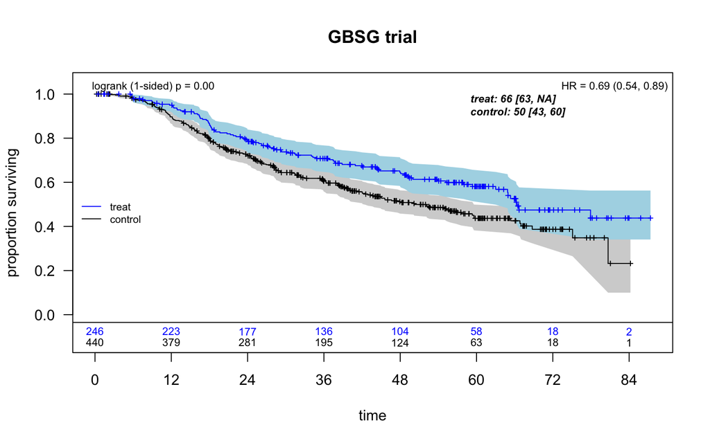

```r
dfcount_gbsg <- df_counting(df_gbsg, tte.name, event.name, treat.name, by.risk = 12)

par(mfrow=c(1,1))
plot_weighted_km(dfcount_gbsg, conf.int = TRUE, show.logrank = TRUE,
                 put.legend.lr = "topleft", ymax = 1.05, xmed.fraction = 0.65)
title(main="GBSG trial")
```

## Subgroup identification analysis

```r
# Baseline factors from which candidate subgroups are formed
confounders.name<-c("age","meno","size","grade3","nodes","pgr","er")

library(doFuture)
library(doRNG)
```

```
## GRF stage for cut selection with dmin,tau= 12 0.6
## tau, maxdepth = 46.75811 2
##    leaf.node control.mean control.size control.se depth
## 1          2         6.49        82.00       3.34     1
## 2          3        -4.10       604.00       1.06     1
## 11         4        -7.90       112.00       2.81     2
## 21         5         3.86       177.00       1.87     2
## 4          7        -5.89       356.00       1.33     2
##
## Selected subgroup:
##   leaf.node control.mean control.size control.se depth
## 1         2         6.49        82.00       3.34     1
##
## GRF subgroup found
## Terminating node at max.diff (sg.harm.id):
## [1] "er <= 0"
##
## All splits:
## [1] "er <= 0"   "age <= 50" "age <= 43"
## # of continuous/categorical characteristics 5 2
## Continuous characteristics: age size nodes pgr er
## Categorical characteristics: meno grade3
## ## Prior to lasso: age size nodes pgr er
## #### Lasso selection results
## 7 x 1 sparse Matrix of class "dgCMatrix"
##                  s0
## age     .
## meno    .
## size    0.005433435
## grade3  0.178139021
## nodes   0.049670523
## pgr    -0.001812895
## er      .
## Cox-LASSO selected: size grade3 nodes pgr
## Cox-LASSO not selected: age meno er
## ### End Lasso selection
## ## After lasso: size nodes pgr
## Default cuts included from Lasso: size <= mean(size) size <= median(size) size <= qlow(size) size <= qhigh(size) nodes <= mean(nodes) nodes <= median(nodes) nodes <= qlow(nodes) nodes <= qhigh(nodes) pgr <= mean(pgr) pgr <= median(pgr) pgr <= qlow(pgr) pgr <= qhigh(pgr)
## Categorical after Lasso: grade3
## Factors per GRF: er <= 0 age <= 50 age <= 43
```

[output cut: 37 more lines]

```
## 19 pgr <= 131.8    q19  0.0201
## 5       er <= 1     q5  0.0192
## 4     age <= 65     q4  0.0093
## Number of possible configurations (<= maxk): maxk = 2 , # combinations = 820
## Events criteria: control >= 10 , treatment >= 10
## Subgroup search completed in 0.02 minutes
## Found 30 subgroup candidate(s)
## # of candidate subgroups (meeting all criteria) = 30
## Removed 1 near-duplicate subgroups
## Original rows: 30
## After removal: 29
## # of unique initial candidates: 29
## # Restricting to top stop_Kgroups = 10
## # of candidates restricted to 'top K': 10
## Using parallel processing: callr with 12 workers
```

```
## Parallel plan: callr with 12 workers.
```

```
## Consistency met!
## # of splits = 1000
## **** Subgroup, % Consistency Met= {er <= 0} {size <= 35} 0.98
## Consistency met!
## # of splits = 1000
## **** Subgroup, % Consistency Met= {er <= 0} {nodes <= 7} 0.95
## Consistency met!
## # of splits = 1000
## **** Subgroup, % Consistency Met= {er <= 0} {pgr <= 32.5} 0.98
## Consistency met!
## # of splits = 1000
## **** Subgroup, % Consistency Met= {er <= 0} !{age <= 43} 0.97
## Consistency met!
## # of splits = 1000
## **** Subgroup, % Consistency Met= {er <= 0} !{size <= 20} 0.92
## Consistency met!
## # of splits = 1000
## **** Subgroup, % Consistency Met= {er <= 0} {pgr <= 7} 0.91
## Consistency met!
## # of splits = 1000
## **** Subgroup, % Consistency Met= {er <= 0} 0.95
## Consistency met!
## # of splits = 1000
## **** Subgroup, % Consistency Met= {er <= 0} {age <= 65} 0.93
## *** Not met: Subgroup, % Consistency = {grade3} {pgr <= 7} 0.86
## *** Not met: Subgroup, % Consistency = {age <= 50} {pgr <= 7} 0.82
```

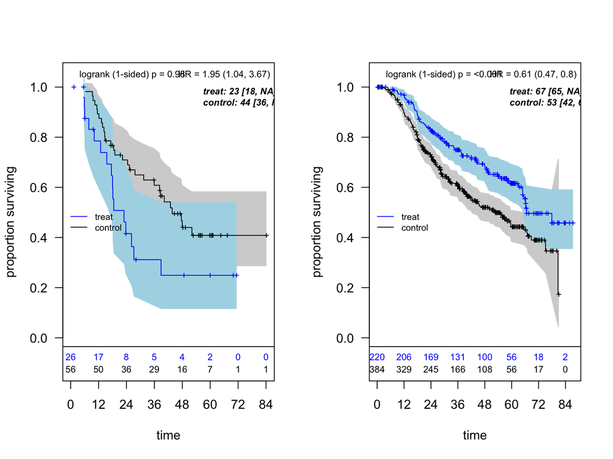

```
## *** Subgroup found: {er <= 0}
## % consistency criteria met= 0.95
## SG focus= hrMaxSG
## Subgroup Consistency Minutes= 0.21665
## Subgroup found (FS) with sg_focus='hrMaxSG'
## Selected subgroup: {er <= 0}
## Minutes forestsearch overall = 0.24
```

```
##    user  system elapsed
##  27.171   1.520  14.403
```

```r
registerDoFuture()
registerDoRNG()

# conf_force 'forces' a specific covariate cut, eg. 'age <= 65'


system.time({fs <- forestsearch(df_gbsg,  confounders.name=confounders.name,
                   outcome.name = "tte", treat.name = "treat", event.name = "event", id.name = "id",
                   hr.threshold = 1.25, hr.consistency = 1.0, pconsistency.threshold = 0.90,
                   sg_focus = "hrMaxSG",
                   showten_subgroups = FALSE, details=TRUE,
                   conf_force = c("age <= 65", "er <= 0", "er <= 1", "er <= 2"," er <= 5"),
                   cut_type = "default", use_grf = TRUE, plot.grf = TRUE, use_lasso = TRUE,
                   maxk = 2, n.min = 60, d0.min = 10, d1.min = 10,
                   plot.sg = TRUE, by.risk = 12,
                   parallel_args = list(plan="callr", workers = 12, show_message = TRUE)
                   )
})
```

```r
# reset workeres
plan("sequential")
```

## Show (up to) top 10 subgroups

```r
res_tabs <- sg_tables(fs, ndecimals = 3)
res_tabs$sg10_out
```

**Identified Subgroups**

Two-factor subgroups (maxk=2)

| Factor 1 | Factor 2 | N | Events | E₁ | HR | P<sub>cons</sub> |
| --- | --- | --- | --- | --- | --- | --- |
| {er <= 0} |  | 82 | 45 | 16 | 1.951 | 0.950 |
| {er <= 0} | {age <= 65} | 76 | 40 | 14 | 1.909 | 0.930 |
| {er <= 0} | {pgr <= 32.5} | 75 | 41 | 16 | 2.222 | 0.980 |
| {er <= 0} | !{age <= 43} | 68 | 38 | 14 | 2.164 | 0.970 |
| {er <= 0} | {pgr <= 7} | 64 | 34 | 13 | 1.992 | 0.910 |
| {er <= 0} | {size <= 35} | 61 | 34 | 15 | 2.537 | 0.980 |
| {er <= 0} | {nodes <= 7} | 61 | 31 | 11 | 2.335 | 0.950 |
| {er <= 0} | !{size <= 20} | 61 | 35 | 12 | 2.054 | 0.920 |

**Search Configuration:** Single-factor candidates (L) = 40; Maximum combinations evaluated = 820; Search depth (maxk) = 2  
**Search Results:** Candidate subgroups found = 30; Maximum HR estimate = 2.54  
**Note:** E₁ = events in treatment arm; P<sub>cons</sub> = consistency proportion

## Un-adjusted summary estimates

```r
res_tabs$tab_estimates
```

**Treatment Effect Estimates**

Training data estimates

| Subgroup | n | n1 | events | m1 | m0 | RMST | HR (95% CI) |
| --- | --- | --- | --- | --- | --- | --- | --- |
| ITT | 686 (100.0%) | 246 (35.9%) | 299 (43.6%) | 66.3 | 50.2 | 7.8 | 0.69 (0.54, 0.89) |
| Questionable | 82 (12.0%) | 26 (31.7%) | 45 (54.9%) | 22.9 | 43.7 | -14 | 1.95 (1.04, 3.67) |
| Recommend | 604 (88.0%) | 220 (36.4%) | 254 (42.1%) | 66.7 | 52.6 | 9.3 | 0.61 (0.47, 0.80) |

## Bootstrap bias-correction and 95% CI estimation

```r
# Just run a few for illustration
# In practice, recommend minimum of NB = 300 to 400 re-samples

# patchhwork needed for a combined bootstrap plot (otherwise if not avaialable will not produce)
library(patchwork)

output_dir <- "results/"
save_results <- dir.exists(output_dir)

NB <- 1000

t.start <- proc.time()[3]

fs_bc <- forestsearch_bootstrap_dofuture(fs.est = fs, nb_boots = NB, show_three = FALSE, details = TRUE)

plan("sequential")

t.now<-proc.time()[3]
t.min<-(t.now-t.start)/60
cat("Minutes (total) for bootstrap (boots,mins)",c(NB,t.min),"\n")
cat("Projected minutes for 1000",c(t.min*(1000/NB)),"\n")


if (save_results) {
    filename <- file.path(output_dir,
                         paste0("gbsg_results_B=",
                                format(NB),
                                ".RData"))
    save(fs_bc, fs, file = filename)
    cat("\nResults saved to:", filename, "\n")
}
```

```r
load("~/Documents/GitHub/forestsearch/vignettes/results/gbsg_results_B=1000.RData")

summaries <- summarize_bootstrap_results(
      sgharm = fs$sg.harm,
      boot_results = fs_bc,
      create_plots = TRUE,
      est.scale = "hr"
    )
```

```
##
## ═══════════════════════════════════════════════════════════════
##            BOOTSTRAP ANALYSIS SUMMARY
## ═══════════════════════════════════════════════════════════════
##
## BOOTSTRAP SUCCESS METRICS:
## ─────────────────────────────────────────────────────────────
##   Total iterations:              1000
##   Successful subgroup ID:        949 (94.9%)
##   Failed to find subgroup:       51 (5.1%)
##
## TIMING ANALYSIS:
## ─────────────────────────────────────────────────────────────
## Overall:
##   Total bootstrap time:          30.22 minutes (0.50 hours)
##   Average per iteration:         0.03 min (1.8 sec)
##
## Per-iteration timing:
##   Mean:                          0.36 min (21.4 sec)
##   Median:                        0.36 min (21.5 sec)
##   Std Dev:                       0.06 minutes
##   Range:                         [0.02, 0.47] minutes
##   IQR:                           [0.34, 0.39] minutes
##
## ForestSearch timing (successful iterations only):
##   Iterations with FS:            1000 (100.0%)
##   Mean FS time:                  0.36 min (21.4 sec)
##   Median FS time:                0.36 min (21.5 sec)
##   Total FS time:                 355.95 minutes
##   FS time % of total:            1178.0%
##
## Overhead timing (Cox models, bias correction, etc.):
##   Mean overhead:                 0.00 min (0.0 sec)
##   Median overhead:               0.00 min (0.0 sec)
##   Total overhead:                0.18 minutes
##   Overhead % of total:           0.6%
##
## PERFORMANCE ASSESSMENT:
## ─────────────────────────────────────────────────────────────
##   Performance rating:            ✓✓✓ Excellent
##   Average iteration speed:       1.8 seconds
##
## ═══════════════════════════════════════════════════════════════
```

```r
sg_tab <- summaries$table

sg_tab
```

**Treatment Effect by Subgroup**

Bootstrap bias-corrected estimates (1000 iterations)

| Subgroup | Sample Size N | Sample Size N<sub>T</sub> | Sample Size Events | Survival Med<sub>T</sub> | Survival Med<sub>C</sub> | Survival RMST<sub>d</sub> | Treatment Effect HR (95% CI)†<sup>1</sup> | Treatment Effect HR‡ (95% CI)<sup>2</sup> |
| --- | --- | --- | --- | --- | --- | --- | --- | --- |
| Qstnbl | 82 (12.0%) | 26 (31.7%) | 45 (54.9%) | 22.9 | 43.7 | -14 | 1.95 (1.04, 3.67) | 1.55 (0.81,2.98) |
| Recmnd | 604 (88.0%) | 220 (36.4%) | 254 (42.1%) | 66.7 | 52.6 | 9.3 | 0.61 (0.47, 0.80) | 0.64 (0.44,0.93) |

<sup>1</sup> **Unadjusted HR**: Standard Cox regression hazard ratio with robust standard errors  
<sup>2</sup> **Bias-corrected HR**: Bootstrap-adjusted estimate using infinitesimal jacknife method (1000 iterations). Corrects for optimism in subgroup selection.  
*Note*: Med = Median survival time (months). RMST<sub>d</sub> = Restricted mean survival time difference. Subgroup identified in 94.9% of bootstrap samples.

```r
event_summary <- summarize_bootstrap_events(fs_bc, threshold = 12)
```

```
##
## === Bootstrap Event Count Summary ===
## Total bootstrap iterations: 1000
## Event threshold: <12 events
##
## ORIGINAL Subgroup H on BOOTSTRAP samples:
##   Control arm <12 events: 0 (0.0%)
##   Treatment arm <12 events: 0 (0.0%)
##   Either arm <12 events: 0 (0.0%)
##
## ORIGINAL Subgroup Hc on BOOTSTRAP samples:
##   Control arm <12 events: 0 (0.0%)
##   Treatment arm <12 events: 0 (0.0%)
##   Either arm <12 events: 0 (0.0%)
##
## NEW Subgroups found: 949 (94.9%)
##
## NEW Subgroup H* on ORIGINAL data:
##   Control arm <12 events: 18 (1.9% of successful)
##   Treatment arm <12 events: 30 (3.2% of successful)
##   Either arm <12 events: 47 (5.0% of successful)
##
## NEW Subgroup Hc* on ORIGINAL data:
##   Control arm <12 events: 0 (0.0% of successful)
##   Treatment arm <12 events: 0 (0.0% of successful)
##   Either arm <12 events: 0 (0.0% of successful)
```

```r
summaries$diagnostics_table_gt
```

**Bootstrap Diagnostics Summary**

Analysis of 1000 bootstrap iterations

| Category | Metric | Value |
| --- | --- | --- |
| Success Rate<sup>1</sup> | Total iterations | 1000 |
|  | Successful subgroup ID | 949 (94.9%) |
|  | Failed to find subgroup | 51 (5.1%) |
|  | Success rating | Excellent ✓✓✓ |
| Subgroup H (Questionable) | Unadjusted estimate | 1.95 (1.04, 3.67) |
|  | Bias-corrected estimate | 1.55 (0.81, 2.98) |
|  | Bias correction impact<sup>2</sup> | 20.6% |
|  | CI width change<sup>3</sup> | 2.64 → 2.17 |
| Subgroup Hc (Recommend) | Unadjusted estimate | 0.61 (0.47, 0.80) |
|  | Bias-corrected estimate | 0.64 (0.44, 0.93) |
|  | Bias correction impact<sup>2</sup> | 4.8% |
|  | CI width change<sup>3</sup> | 0.33 → 0.49 |
| Bootstrap Quality: H | Valid iterations | 949 |
|  | Mean (SD) | 0.44 (0.43) |
|  | Coefficient of variation<sup>4</sup> | 97.2% |
|  | Skewness<sup>5</sup> | -0.21 |
| Bootstrap Quality: Hc | Valid iterations | 949 |
|  | Mean (SD) | -0.44 (0.22) |
|  | Coefficient of variation<sup>4</sup> | 49.0% |
|  | Skewness<sup>5</sup> | 0.21 |
| Search Performance | Mean max HR found | 3.34 (1.28) |
|  | Mean factors evaluated | 48.5 |
|  | Mean combinations tried | 1231 |
|  | Proportion at maxk | — |

<sup>1</sup> **Success Rate**: Proportion of bootstrap samples where ForestSearch identified a valid subgroup  
<sup>2</sup> **Bias Correction Impact**: Percentage change from unadjusted to bias-corrected estimate  
<sup>3</sup> **CI Width Change**: Confidence interval width before → after bias correction  
<sup>4</sup> **Coefficient of Variation**: Standard deviation as % of mean (lower is better)  
<sup>5</sup> **Skewness**: Measure of asymmetry (0 = symmetric, |skew| < 1 is generally good)  
**Interpretation Guide:** ✓ **Excellent stability**: Subgroup is consistently identified across bootstrap samples. ⚠ **High variability**: Bootstrap estimates are imprecise (CV ≥ 25%). Consider increasing nb_boots or sample size.

```r
summaries$subgroup_summary$original_agreement
```

```r
#summaries$subgroup_summary$agreement

summaries$subgroup_summary$factor_presence
```

```
##     Rank   Factor Count   Percent
##    <int>   <char> <int>     <num>
## 1:     1       er   508 53.530032
## 2:     2      age   364 38.356164
## 3:     3      pgr   329 34.668072
## 4:     4     size   211 22.233930
## 5:     5    nodes   106 11.169652
## 6:     6   grade3    75  7.903056
## 7:     7  er <= 5    70  7.376185
## 8:     8     meno    54  5.690200
```

```r
summaries$subgroup_summary$factor_presence_specific
```

```
##     Rank Base_Factor Factor_Definition Count  Percent
##    <int>      <char>            <char> <int>    <num>
## 1:     1          er         {er <= 0}   222 23.39305
```

[figure not shown]

```r
summaries$plots$combined
```

## Decision Function

```r
#' Decide sg_focus Based on Study Goal
#'
#' @param study_goal Character string indicating the primary study goal
#' @return Recommended sg_focus setting
#' @examples
#' decide_sg_focus("regulatory_safety")
#' decide_sg_focus("population_health")

decide_sg_focus <- function(study_goal) {

  decision_map <- list(
    "regulatory_safety" = "hr",        # Most reliable evidence
    "population_health" = "maxSG",     # Protect most patients
    "precision_medicine" = "minSG",    # Most targeted restriction
    "benefit_risk_balance" = "hrMaxSG", # Large group with meaningful harm
    "biomarker_development" = "hrMinSG" # Specific high-risk signature
  )

  if (!study_goal %in% names(decision_map)) {
    stop("Unknown study goal. Choose from: ",
         paste(names(decision_map), collapse = ", "))
  }

  sg_focus <- decision_map[[study_goal]]

  cat("Study Goal:", study_goal, "\n")
  cat("Recommended sg_focus:", sg_focus, "\n")

  return(sg_focus)
}

# Example usage
decide_sg_focus("regulatory_safety")
```

```
## Study Goal: regulatory_safety
## Recommended sg_focus: hr
```

```
## [1] "hr"
```

# Impact on Algorithm Behavior

## Internal Sorting Logic

```r
# From subgroup_consistency.R
sort_subgroups <- function(result_new, sg_focus) {
  if (sg_focus == "hr")
    data.table::setorder(result_new, -Pcons, -hr, K)  # Reliability first

  if (sg_focus %in% c("hrMaxSG", "maxSG"))
    data.table::setorder(result_new, -N, -Pcons, K)   # Size first

  if (sg_focus %in% c("hrMinSG", "minSG"))
    data.table::setorder(result_new, N, -Pcons, K)    # Specificity first

  result_new
}
```

## Parameter Interactions

Typical Parameter Settings by sg_focus

| sg_focus | Typical hr.threshold | Typical pconsistency.threshold | stop.threshold |
| --- | --- | --- | --- |
| hr | 1.25 (moderate) | 0.90 (high) | 0.90 |
| maxSG | 1.10 (low) | 0.85 (moderate) | Variable* |
| minSG | 1.50 (high) | 0.85 (moderate) | Variable* |
| hrMaxSG | 1.30 (moderate) | 0.90 (high) | 1.00 |
| hrMinSG | 1.50 (high) | 0.90 (high) | 1.00 |

*Variable stop.threshold for size-based focus requires special handling based on the specific analysis goals.

# Practical Examples by Study Type

## Phase II Safety Study

```r
# Option 1: Find most reliable signal
result_reliable <- forestsearch(
  df.analysis = phase2_data,
  sg_focus = "hr",              # Most reliable signal
  hr.threshold = 1.25,
  pconsistency.threshold = 0.85,
  n.min = 30,                   # Smaller sample OK for phase II
  d0.min = 5,
  d1.min = 5
)

# Option 2: Find highest-risk profile
result_highrisk <- forestsearch(
  df.analysis = phase2_data,
  sg_focus = "minSG",           # Most specific risk
  hr.threshold = 1.5,           # Higher threshold
  pconsistency.threshold = 0.80,
  n.min = 20,                   # Very specific groups OK
  d0.min = 5,
  d1.min = 5
)
```

## Phase III Confirmatory Trial

```r
# Option 1: Regulatory standard
result_regulatory <- forestsearch(
  df.analysis = phase3_data,
  sg_focus = "hr",              # Regulatory standard
  hr.threshold = 1.3,
  pconsistency.threshold = 0.95, # Very high confidence
  n.min = 100,                  # Large samples required
  d0.min = 20,
  d1.min = 20
)

# Option 2: If population impact matters
result_population <- forestsearch(
  df.analysis = phase3_data,
  sg_focus = "hrMaxSG",         # Balance effect and size
  hr.threshold = 1.3,
  hr.consistency = 1.15,        # Must maintain effect
  pconsistency.threshold = 0.90,
  n.min = 80
)
```

## Post-Market Surveillance

```r
# Population protection priority
result_surveillance <- forestsearch(
  df.analysis = realworld_data,
  sg_focus = "maxSG",           # Protect most patients
  hr.threshold = 1.15,          # Lower threshold for safety
  pconsistency.threshold = 0.85,
  n.min = 100,
  d0.min = 15,
  d1.min = 15
)
```

## Biomarker Development

```r
# Specific signature with large effect
result_biomarker <- forestsearch(
  df.analysis = biomarker_trial,
  sg_focus = "hrMinSG",         # Specific + harmful
  hr.threshold = 2.0,           # Large effect required
  hr.consistency = 1.5,         # Must maintain large effect
  pconsistency.threshold = 0.90,
  n.min = 30,                   # Small specific groups OK
  d0.min = 10,
  d1.min = 10
)
```

# Accessing Results

## Understanding Output Structure

```r
# The grp.consistency object contains results for all approaches
fs_result <- forestsearch(df.analysis = trial_data, sg_focus = "hr")

# Access different sorting results
hr_results <- fs_result$grp.consistency$out_hr      # Sorted by HR priority
maxSG_results <- fs_result$grp.consistency$out_maxSG # Sorted by size (large)
minSG_results <- fs_result$grp.consistency$out_minSG # Sorted by size (small)

# The final selection depends on sg_focus
final_subgroup <- fs_result$sg.harm  # This is determined by sg_focus

# View top 10 candidates by different criteria
if (!is.null(hr_results)) {
  print(hr_results$result[1:min(10, nrow(hr_results$result)), ])
}
```

## Comparing Different sg_focus Results

```r
# Run same analysis with different sg_focus settings
compare_sg_focus <- function(df, ...) {

  focus_options <- c("hr", "maxSG", "minSG", "hrMaxSG", "hrMinSG")
  results <- list()

  for (focus in focus_options) {
    cat("\nRunning with sg_focus =", focus, "\n")

    res <- forestsearch(
      df.analysis = df,
      sg_focus = focus,
      details = FALSE,
      ...
    )

    if (!is.null(res$sg.harm)) {
      results[[focus]] <- list(
        subgroup = res$sg.harm,
        size = sum(res$df.est$treat.recommend == 0),
        consistency = res$grp.consistency$out_hr$result$Pcons[1]
      )
    } else {
      results[[focus]] <- "No subgroup found"
    }
  }

  return(results)
}

# Example usage
comparison <- compare_sg_focus(
  df = trial_data,
  hr.threshold = 1.25,
  pconsistency.threshold = 0.85,
  n.min = 50
)
```

# Statistical Considerations

## Power Trade-offs

Power and Impact Trade-offs by sg_focus

| sg_focus | Statistical_Power | Effect_Size | Clinical_Impact |
| --- | --- | --- | --- |
| maxSG | Higher (more patients) | Potentially diluted | Broad restrictions |
| minSG | Lower (fewer patients) | Potentially stronger | Targeted restrictions |
| hr | Balanced | Based on consistency | Evidence-based restrictions |

## Implicit Utility Functions

```r
# Utility function implicit in each focus

utility_hr <- function(subgroup) {
  # Maximize: consistency * effect_size
  subgroup$Pcons * subgroup$hr
}

utility_maxSG <- function(subgroup) {
  # Maximize: affected_population * (effect > threshold)
  subgroup$N * (subgroup$hr > hr.threshold)
}

utility_minSG <- function(subgroup) {
  # Maximize: specificity * effect_size
  (1/subgroup$N) * subgroup$hr
}

utility_hrMaxSG <- function(subgroup, hr.threshold) {
  # Maximize: size | hr > threshold
  ifelse(subgroup$hr > hr.threshold, subgroup$N, 0)
}

utility_hrMinSG <- function(subgroup, hr.threshold) {
  # Maximize: specificity | hr > threshold
  ifelse(subgroup$hr > hr.threshold, 1/subgroup$N * subgroup$hr, 0)
}
```

# Sensitivity Analysis

## Testing Multiple sg_focus Settings

```r
# Sensitivity analysis across sg_focus options
run_sg_sensitivity <- function(df, base_params) {

  focus_grid <- c("hr", "maxSG", "minSG", "hrMaxSG", "hrMinSG")

  results <- data.frame(
    sg_focus = character(),
    subgroup_found = logical(),
    subgroup_size = integer(),
    subgroup_hr = numeric(),
    consistency = numeric(),
    n_factors = integer(),
    stringsAsFactors = FALSE
  )

  for (focus in focus_grid) {
    res <- do.call(forestsearch, c(
      list(df.analysis = df, sg_focus = focus),
      base_params
    ))

    if (!is.null(res$sg.harm)) {
      results <- rbind(results, data.frame(
        sg_focus = focus,
        subgroup_found = TRUE,
        subgroup_size = sum(res$df.est$treat.recommend == 0),
        subgroup_hr = res$grp.consistency$out_hr$result$hr[1],
        consistency = res$grp.consistency$out_hr$result$Pcons[1],
        n_factors = length(res$sg.harm),
        stringsAsFactors = FALSE
      ))
    } else {
      results <- rbind(results, data.frame(
        sg_focus = focus,
        subgroup_found = FALSE,
        subgroup_size = NA,
        subgroup_hr = NA,
        consistency = NA,
        n_factors = NA,
        stringsAsFactors = FALSE
      ))
    }
  }

  return(results)
}

# Example usage
base_params <- list(
  hr.threshold = 1.25,
  pconsistency.threshold = 0.85,
  n.min = 50,
  d0.min = 10,
  d1.min = 10
)

sensitivity_results <- run_sg_sensitivity(trial_data, base_params)
print(sensitivity_results)
```

# Key Insights and Recommendations

## Philosophy of Each Approach

|  | sg_focus | Core_Question | Statistical_Philosophy | Clinical_Philosophy |
| --- | --- | --- | --- | --- |
| 1 | hr | What harm are we most sure about? | Maximize reliability | Evidence-based medicine |
| 2 | maxSG | How many patients could we protect? | Maximize coverage | Population health |
| 3 | minSG | Who is at highest risk? | Maximize specificity | Precision medicine |
| 4 | hrMaxSG | What's the biggest problem we're confident about? | Balance impact and confidence | Risk-benefit optimization |
| 5 | hrMinSG | What's the most specific serious risk? | Precision with significance | Targeted intervention |

## Summary Recommendations

1. **Start with `sg_focus = "hr"`** for initial exploration - most balanced approach
2. **Consider your stakeholders**:
- Regulators → “hr”
- Health systems → “maxSG”
- Precision medicine → “minSG” or “hrMinSG”
3. **Run sensitivity analyses** with multiple sg_focus settings
4. **Document your choice** and rationale in study protocols
5. **Report results from multiple perspectives** even if one is primary

## Final Notes

- All sg_focus options evaluate the **same candidate subgroups**
  - The parameter only affects **which one is selected as primary**
  - No additional multiple testing burden between options
- Consider pre-specifying sg_focus in your statistical analysis plan

*This document provides comprehensive guidance on the sg_focus parameter in ForestSearch. Each option represents a valid statistical and clinical perspective on subgroup identification for treatment harm.*

# Required R Packages for ForestSearch Analysis

1. **grf**
   - Generalized Random Forests for causal inference and subgroup identification.
2. **policytree**
   - Policy learning and tree-based subgroup identification.
3. **data.table**
   - Fast and memory-efficient data manipulation.
4. **randomForest**
   - Random forest algorithms for variable selection and prediction.
5. **survival**
   - Survival analysis, including Cox proportional hazards models.
6. **weightedSurv**
   - Weighted survival curves and related methods.
7. **future.apply**
   - Parallelization of apply functions using the future framework.
8. **foreach**
   - Looping construct for parallel execution.
9. **doFuture**
   - Backend for foreach to enable parallelization with future.
10. **doRNG**
    - Reproducible parallel foreach loops.
11. **DiagrammeR**
    - Visualization of diagrams and flowcharts (used for schematic diagrams).

## Usage Notes

- All packages should be installed before running the analysis.
- Some packages (e.g., `DiagrammeR`) are only needed for visualization and not for the core analysis.
- The function `ensure_packages()` in your code can be used to check and install missing packages automatically.

# Installing Required R Packages for ForestSearch Analysis

To run ForestSearch and its associated bootstrap/validation workflow, you need to install the following R packages:

- grf
- policytree
- data.table
- randomForest
- survival
- weightedSurv
- future.apply
- foreach
- doFuture
- doRNG
- DiagrammeR

You can install all these packages from CRAN using the following R code:

```r
# List of required packages
required_packages <- c(
  'grf', 'policytree', 'data.table', 'randomForest', 'survival',
  'future.apply', 'foreach', 'doFuture', 'doRNG', 'DiagrammeR'
)

# Install any packages that are not already installed
new_packages <- required_packages[!(required_packages %in% installed.packages()[,'Package'])]
if(length(new_packages)) install.packages(new_packages)

# Load all packages
lapply(required_packages, library, character.only = TRUE)

# For weightedSurv, at the time of this note, is only available on github

library(devtools)
install_github("larry-leon/weightedSurv")
```

**Notes:** - You only need to run the installation code once per R environment. - If you encounter any errors, make sure your R version is up to date and you have internet access. - Some packages (e.g., `DiagrammeR`) are only needed for visualization and not for the core analysis.

# Summary of forestsearch_bootstrap_dofuture.R

This file provides functions for bootstrapping analysis in ForestSearch, with parallelization using doFuture.

## Key Functions

### ensure_packages

Installs and loads required packages if not already available. - **Arguments:** pkgs (character vector of package names) - **Returns:** None (loads packages)

### build_cox_formula

Constructs a Cox model formula from variable names. - **Arguments:** outcome.name, event.name, treat.name (character) - **Returns:** R formula object for Cox regression

### fit_cox_models

Fits Cox models for two subgroups defined by treatment recommendation. - **Arguments:** df (data frame), formula (Cox model formula) - **Returns:** List with HR and SE for each subgroup

### bootstrap_ystar

Generates a bootstrap matrix for Ystar using parallel processing. - **Arguments:** df (data frame), nb_boots (integer) - **Returns:** Matrix of bootstrap samples

### bootstrap_results

Runs bootstrap analysis for ForestSearch, fitting Cox models and bias correction. - **Arguments:** fs.est (ForestSearch results), df_boot_analysis (data frame), cox.formula.boot (formula), nb_boots (integer), show_three (logical), H_obs, Hc_obs (numeric), reset_parallel (logical), boot_workers (integer) - **Returns:** Data.table with bias-adjusted estimates and search metrics

### format_CI

Formats confidence interval for estimates. - **Arguments:** estimates (data frame/data.table), col_names (character vector) - **Returns:** Character string formatted as ‘estimate (lower, upper)’

### forestsearch_bootstrap_dofuture

Orchestrates bootstrap analysis for ForestSearch using doFuture parallelization. - **Arguments:** fs.est (ForestSearch results), nb_boots (integer), details (logical), show_three (logical), reset_parallel_fs (logical), boot_workers (integer), parallel_args (list) - **Returns:** List with bootstrap results, confidence intervals, summary table, Ystar matrix, and estimates

## Usage Notes

- Ensure all required packages are installed before running bootstrap analysis.
- The main function for analysis is `forestsearch_bootstrap_dofuture`, which returns a comprehensive list of results for downstream analysis and reporting.
- Parallelization is handled via doFuture and foreach for efficient computation.

# Overview of Main functions

[interactive chart not shown]

Figure 2: Main functions

# Overview of Helper Functions

[interactive chart not shown]

Figure 3: Helpers functions

# Overview of all functions

[interactive chart not shown]

Figure 4: Overview of ALL functions